# R Notebook

#### Objectif TD : Analyse exploratoire

> Rappel :

#### Univarié

> Test d’adéquation pour savoir si suit une loi.

#### Bivarié

> - Comparaison de moyenne Student
> - Test d’independance Chi-square

# Exercice 1

```r
load("../TP01/donnees/iris.Rdata")
```

```r
data(iris)
class(iris)
```

```
[1] "data.frame"
```

```r
names(iris)
```

```
[1] "Sepal.Length" "Sepal.Width"  "Petal.Length" "Petal.Width"  "Species"
```

```r
iris[, 1]
```

```
  [1] 5.1 4.9 4.7 4.6 5.0 5.4 4.6 5.0 4.4 4.9 5.4 4.8 4.8 4.3 5.8 5.7 5.4 5.1 5.7 5.1 5.4 5.1
 [23] 4.6 5.1 4.8 5.0 5.0 5.2 5.2 4.7 4.8 5.4 5.2 5.5 4.9 5.0 5.5 4.9 4.4 5.1 5.0 4.5 4.4 5.0
 [45] 5.1 4.8 5.1 4.6 5.3 5.0 7.0 6.4 6.9 5.5 6.5 5.7 6.3 4.9 6.6 5.2 5.0 5.9 6.0 6.1 5.6 6.7
 [67] 5.6 5.8 6.2 5.6 5.9 6.1 6.3 6.1 6.4 6.6 6.8 6.7 6.0 5.7 5.5 5.5 5.8 6.0 5.4 6.0 6.7 6.3
 [89] 5.6 5.5 5.5 6.1 5.8 5.0 5.6 5.7 5.7 6.2 5.1 5.7 6.3 5.8 7.1 6.3 6.5 7.6 4.9 7.3 6.7 7.2
[111] 6.5 6.4 6.8 5.7 5.8 6.4 6.5 7.7 7.7 6.0 6.9 5.6 7.7 6.3 6.7 7.2 6.2 6.1 6.4 7.2 7.4 7.9
[133] 6.4 6.3 6.1 7.7 6.3 6.4 6.0 6.9 6.7 6.9 5.8 6.8 6.7 6.7 6.3 6.5 6.2 5.9
```

```r
iris$Sepal.Length
```

```
  [1] 5.1 4.9 4.7 4.6 5.0 5.4 4.6 5.0 4.4 4.9 5.4 4.8 4.8 4.3 5.8 5.7 5.4 5.1 5.7 5.1 5.4 5.1
 [23] 4.6 5.1 4.8 5.0 5.0 5.2 5.2 4.7 4.8 5.4 5.2 5.5 4.9 5.0 5.5 4.9 4.4 5.1 5.0 4.5 4.4 5.0
 [45] 5.1 4.8 5.1 4.6 5.3 5.0 7.0 6.4 6.9 5.5 6.5 5.7 6.3 4.9 6.6 5.2 5.0 5.9 6.0 6.1 5.6 6.7
 [67] 5.6 5.8 6.2 5.6 5.9 6.1 6.3 6.1 6.4 6.6 6.8 6.7 6.0 5.7 5.5 5.5 5.8 6.0 5.4 6.0 6.7 6.3
 [89] 5.6 5.5 5.5 6.1 5.8 5.0 5.6 5.7 5.7 6.2 5.1 5.7 6.3 5.8 7.1 6.3 6.5 7.6 4.9 7.3 6.7 7.2
[111] 6.5 6.4 6.8 5.7 5.8 6.4 6.5 7.7 7.7 6.0 6.9 5.6 7.7 6.3 6.7 7.2 6.2 6.1 6.4 7.2 7.4 7.9
[133] 6.4 6.3 6.1 7.7 6.3 6.4 6.0 6.9 6.7 6.9 5.8 6.8 6.7 6.7 6.3 6.5 6.2 5.9
```

```r
class(iris[, 1])
```

```
[1] "numeric"
```

```r
class(iris$Species)
```

```
[1] "factor"
```

```r
summary(iris)
```

```
  Sepal.Length    Sepal.Width     Petal.Length    Petal.Width          Species
 Min.   :4.300   Min.   :2.000   Min.   :1.000   Min.   :0.100   setosa    :50
 1st Qu.:5.100   1st Qu.:2.800   1st Qu.:1.600   1st Qu.:0.300   versicolor:50
 Median :5.800   Median :3.000   Median :4.350   Median :1.300   virginica :50
 Mean   :5.843   Mean   :3.057   Mean   :3.758   Mean   :1.199
 3rd Qu.:6.400   3rd Qu.:3.300   3rd Qu.:5.100   3rd Qu.:1.800
 Max.   :7.900   Max.   :4.400   Max.   :6.900   Max.   :2.500
```

```r
apply(iris[, 1:4], 2, mean)
```

```
Sepal.Length  Sepal.Width Petal.Length  Petal.Width
    5.843333     3.057333     3.758000     1.199333
```

```r
cor(iris[, 1:4])
```

```
             Sepal.Length Sepal.Width Petal.Length Petal.Width
Sepal.Length    1.0000000  -0.1175698    0.8717538   0.8179411
Sepal.Width    -0.1175698   1.0000000   -0.4284401  -0.3661259
Petal.Length    0.8717538  -0.4284401    1.0000000   0.9628654
Petal.Width     0.8179411  -0.3661259    0.9628654   1.0000000
```

```r
print(cor(iris[, 1:4]), digits = 3)
```

```
             Sepal.Length Sepal.Width Petal.Length Petal.Width
Sepal.Length        1.000      -0.118        0.872       0.818
Sepal.Width        -0.118       1.000       -0.428      -0.366
Petal.Length        0.872      -0.428        1.000       0.963
Petal.Width         0.818      -0.366        0.963       1.000
```

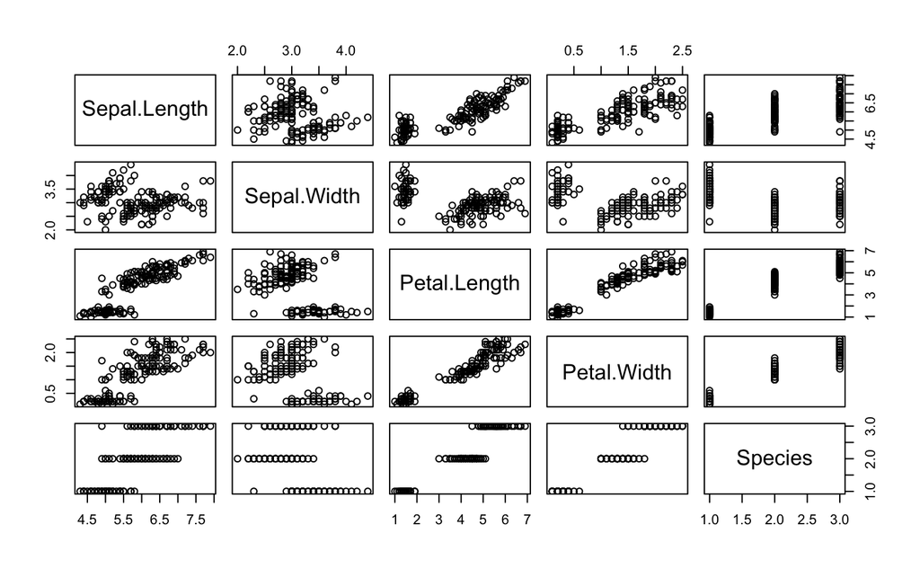

```r
plot(iris)
```

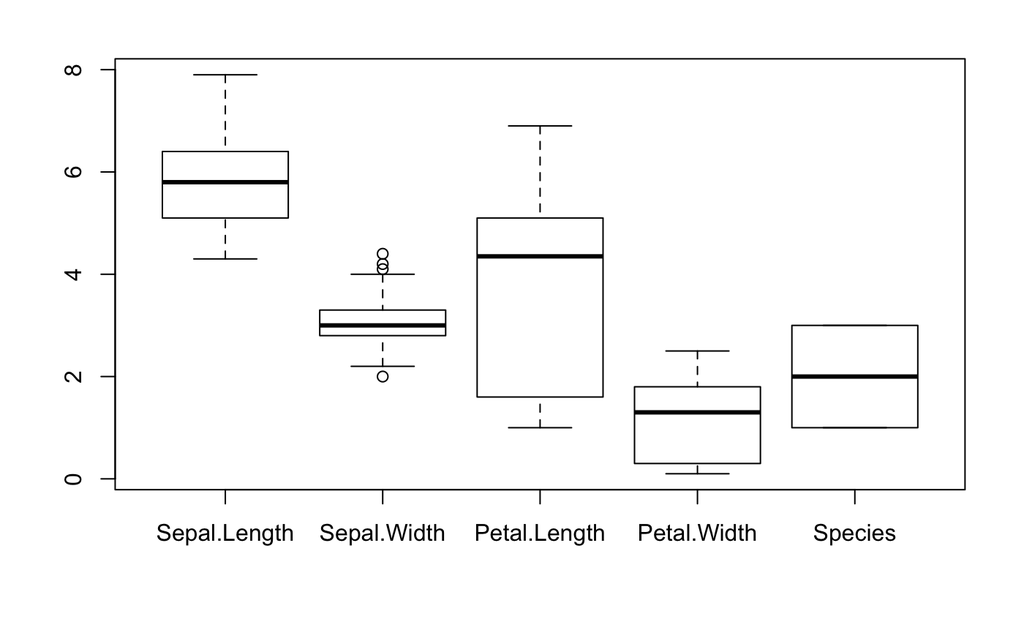

```r
boxplot(iris)
```

Afficher plusieurs graphiques sur la même fenêtre.

Transformer especes en dummy variables ?

```r
setosa <- iris[iris$Species == "setosa",]
versicolor <- iris[iris$Species == "versicolor",]
virginica <- iris[iris$Species == "virginica",]
```

Pas besoin, ici as.numeric le fait comme il faut.

```r
as.numeric(iris$Species)
```

```
  [1] 1 1 1 1 1 1 1 1 1 1 1 1 1 1 1 1 1 1 1 1 1 1 1 1 1 1 1 1 1 1 1 1 1 1 1 1 1 1 1 1 1 1 1 1 1
 [46] 1 1 1 1 1 2 2 2 2 2 2 2 2 2 2 2 2 2 2 2 2 2 2 2 2 2 2 2 2 2 2 2 2 2 2 2 2 2 2 2 2 2 2 2 2
 [91] 2 2 2 2 2 2 2 2 2 2 3 3 3 3 3 3 3 3 3 3 3 3 3 3 3 3 3 3 3 3 3 3 3 3 3 3 3 3 3 3 3 3 3 3 3
[136] 3 3 3 3 3 3 3 3 3 3 3 3 3 3 3
```

```
Error in Summary.factor(c(1L, 1L, 1L, 1L, 1L, 1L, 1L, 1L, 1L, 1L, 1L,  :
  'min' not meaningful for factors
```

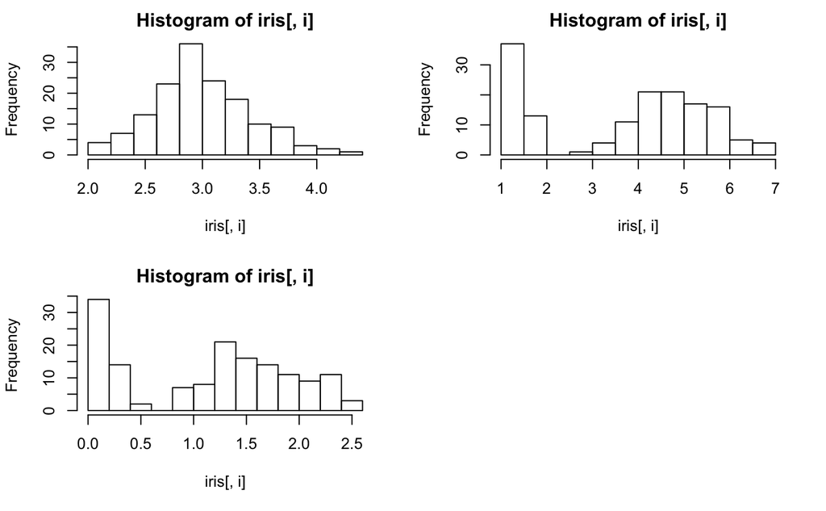

```r
def.par <- par(no.readonly = T)
par(mfrow = c(2, 2))
for (i in 2:5) {
  hist(iris[, i])
}
```

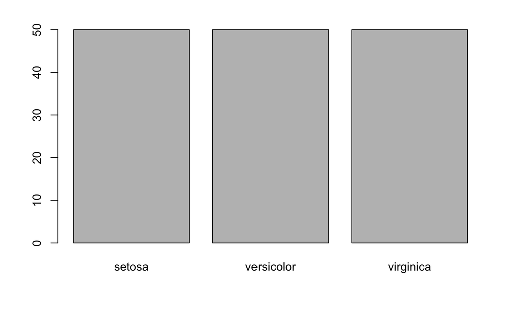

```r
barplot(summary(iris$Species))
```

Cette commande effectue une graphique en baton sur l’effectif de chaque especes d’iris.

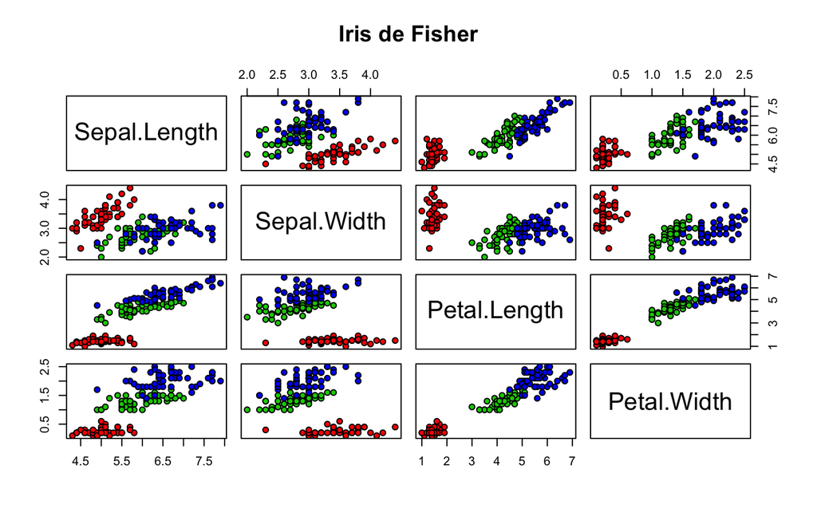

> **Premières conclusions**

> Il semblerait qu’il existe des correlations lineaires entre la longueur des petales et leur largeur.

> De plus, le ratio des caracteristiques sur les sepals par celle sur les petales donne une indication forte sur l’appartenant d’une classe par rapoort au 2 autres. (ici la rouge)

> D’autre part, le ratio de la longueur des petales par les sepales des especes bleus et vertes caracterises bien les deux especes restantes.

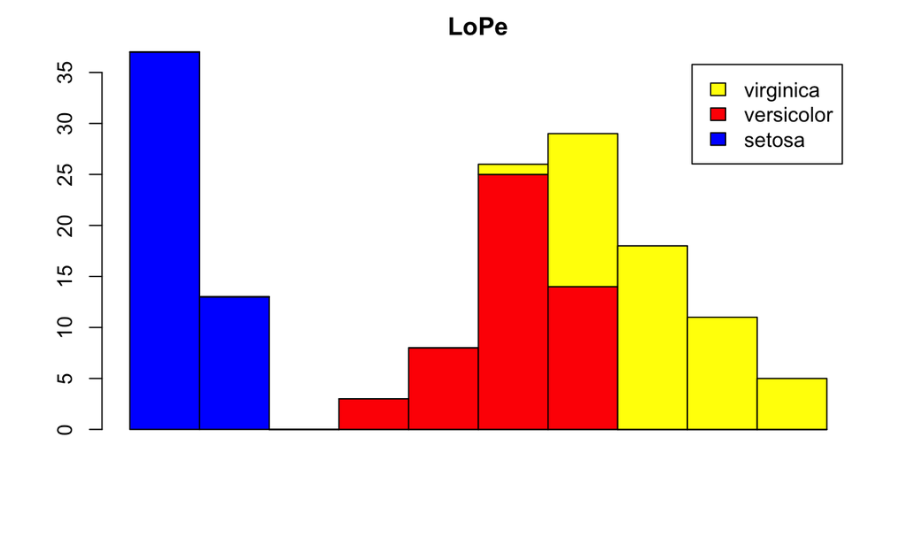

```r
attach(iris)
# Histogrammes avec les espèces en fonction de la taille des pétales
inter <- seq(min(Petal.Length), max(Petal.Length), by = (max(Petal.Length) - min(Petal.Length))/10)
h1 <- hist(plot = F, Petal.Length[Species == "setosa"], breaks = inter)
h2 <- hist(plot = F, Petal.Length[Species == "versicolor"], breaks = inter)
h3 <- hist(plot = F, Petal.Length[Species == "virginica"], breaks = inter)
barplot(rbind(h1$counts, h2$counts, h3$counts), space = 0, legend =levels(Species), main = "LoPe", col = c("blue", "red", "yellow"))
```

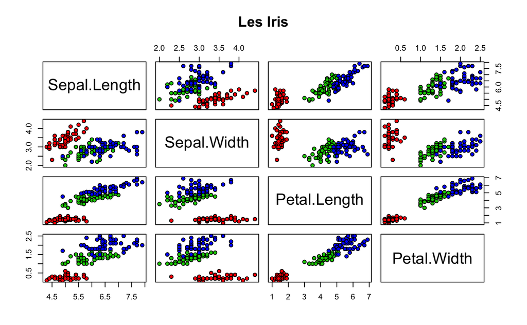

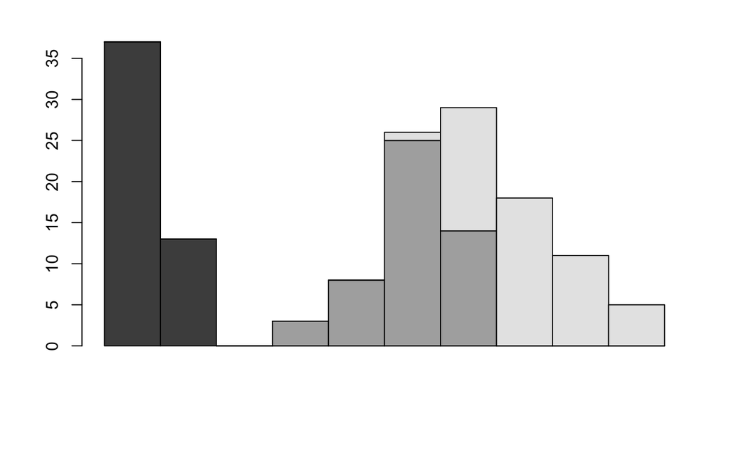

# Exercice 2

> **Test du Chi2**

> Voir si deux variables sont indépendantes Est-il raisonnable de penser que les proportions observés sont proche du produit de la fréquence d’apparition de chaque observation pixpj ?

On utilise `na.strings="ABS"` pour importer les données avec les valeurs initilement en ABS en NA.

```r
median <- read.csv("donnees/median-sy02-p2014.csv", header = FALSE, na.strings="ABS")
```

|  | V1 | V2 |
| --- | --- | --- |
| 2 | GU02 | 10.0 |
| 3 | GU06 | 5.5 |
| 4 | GU01 | 7.5 |
| 5 | GI05 | 11.0 |
| 6 | GB02 | 16.0 |
| 7 | GM02 | 18.5 |
| 8 | GB04 | 8.5 |
| 9 | GP02 | 15.0 |
| 10 | GS04 | 10.5 |
| 11 | GP02 | 14.0 |

[output cut: 265 more lines]

```r
data$V1
```

```
  [1] GU GU GU GI GB GM GB GP GS GP GU GB GS GU GM GS GB MT GS GI MT GP GU GM GP GU GB GB GU GU
 [31] GB GU TC GB GP GM GB GP GU GI GB GB GP GM GS GB GU GP GM GS GU GB GS GM GB GM GB GB GU GM
 [61] GU GM GM TC GP GP GB GM GB GU GI TC GM GS GM GU GP GU GU TC TC GU TC GS GM GB GI GB GS GU
 [91] GP GB GI GU GM GM GB GS GU GM GM GS GS TC TC GM GM GM GS GS GU GM GU GB GS GM GU GM MT GP
[121] GI GS GM GU GS GM GU GS GS GM GU GM GP GB GP GS GB MT GP GM GU GU GI GB GM GB TC GM GB GB
[151] GI GP GU GS GP GB GU GU GM GP GP GM GB GM GI GB GS GU GM GB GM GB GI GM GB GU GU GM GB GM
[181] GM GB GS GS GM GU TC GB GS GS GU GB GS GB GM GI GP GB GS GU GP GM GU GM GB GP TC GM GB GM
[211] GM GU GI GU GM GM GM GS GB GU GU GB GU GP GB GM GI GM GB GM GM GI GI GM GM GM GI GM GS GP
[241] GU GB GP GU GU GB TC GS GM GB GS GI GB GP GB GM GU GM MT GU GI GM TC GS GU GB GB GP GS GB
[271] GB GS GM GM GI
Levels: GB GI GM GP GS GU MT TC
```

On essaye de voir si la branche à une influence sur les résultats.

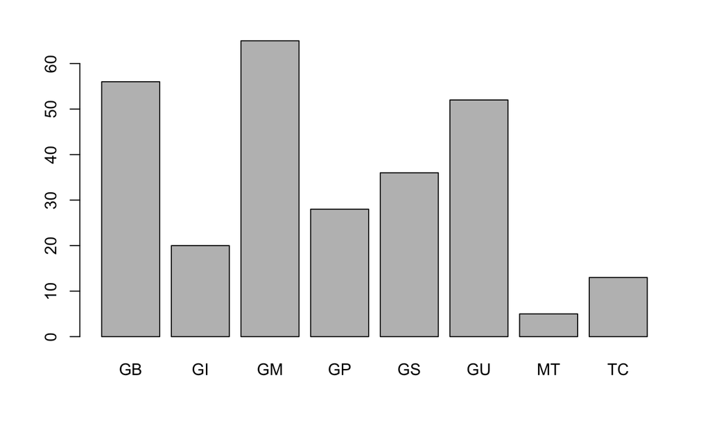

```r
barplot(summary(data$V1))
```

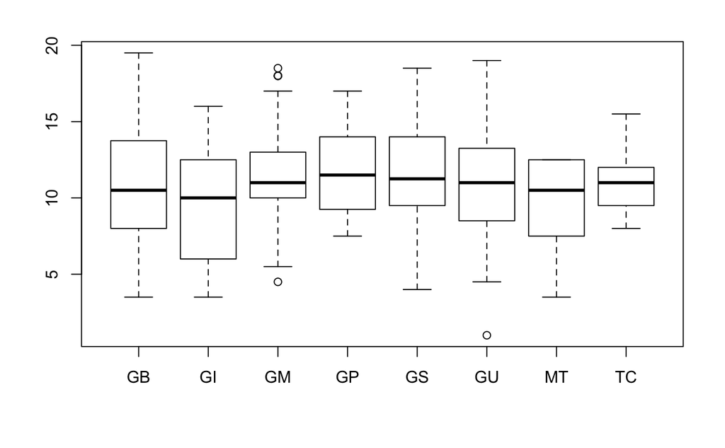

```r
boxplot(data$V2~data$V1)
```

Confirmation par le test du chi2

```
    Chi-squared test for given probabilities

data:  hist.factor(data$V2, data$V1)
X-squared = 16.5, df = 9, p-value = 0.05715
```

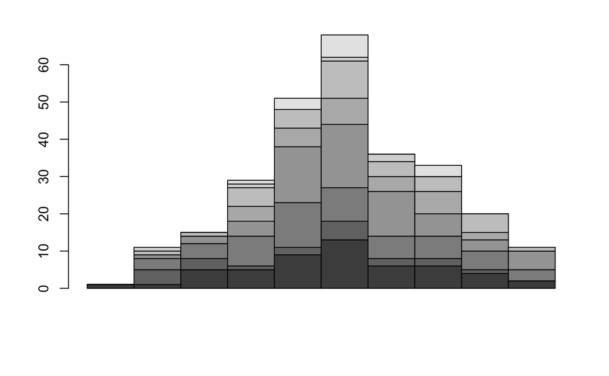

```r
chisq.test(hist.factor(data$V2,data$V1))
```

Il semblerait donc qu’on accepte l’hypothese ($p_{value}$ = 0.05715) d’independance ($H_0$) des branches sur les notes.

Pour comparer les notes entre les etudiants de GI et GP, on effectue une comparaison de moyenne par le test de Student.

```r
t.test(data$V2[data$V1 == 'GI'],data$V2[data$V1 == 'GP'])
```

```
    Welch Two Sample t-test

data:  data$V2[data$V1 == "GI"] and data$V2[data$V1 == "GP"]
t = -2.2956, df = 32.291, p-value = 0.02834
alternative hypothesis: true difference in means is not equal to 0
95 percent confidence interval:
 -4.5423404 -0.2719453
sample estimates:
mean of x mean of y
  9.32500  11.73214
```

Il semblerait donc qu’on rejette l’hypothese ($p_{value}$ = 0.02834) d’égalité des moyennes ($H_0$) des branches GI et GP. Les différences de notes sont significatives.

# Exercice 3

```r
data <- read.table("donnees/babies23.data")
```